# clusters

### Visualização dos Resultados

A visualização dos resultados incluiu gráficos que mostram a variação dos atributos físicos e técnicos.

```python
df = pd.read_csv(r"all_seasons.csv")
```

```python
data_info(df)
```

|  | var | total_missing | pct_missing | types | unique_values |
| --- | --- | --- | --- | --- | --- |
| 0 | Unnamed: 0 | 0 | 0.0 | int64 | 12844 |
| 1 | player_name | 0 | 0.0 | object | 2551 |
| 2 | team_abbreviation | 0 | 0.0 | object | 36 |
| 3 | age | 0 | 0.0 | float64 | 27 |
| 4 | player_height | 0 | 0.0 | float64 | 30 |
| 5 | player_weight | 0 | 0.0 | float64 | 157 |
| 6 | college | 0 | 0.0 | object | 357 |
| 7 | country | 0 | 0.0 | object | 82 |
| 8 | draft_year | 0 | 0.0 | object | 48 |
| 9 | draft_round | 0 | 0.0 | object | 9 |
| 10 | draft_number | 0 | 0.0 | object | 76 |
| 11 | gp | 0 | 0.0 | int64 | 85 |
| 12 | pts | 0 | 0.0 | float64 | 319 |
| 13 | reb | 0 | 0.0 | float64 | 153 |
| 14 | ast | 0 | 0.0 | float64 | 115 |
| 15 | net_rating | 0 | 0.0 | float64 | 772 |
| 16 | oreb_pct | 0 | 0.0 | float64 | 216 |
| 17 | dreb_pct | 0 | 0.0 | float64 | 352 |
| 18 | usg_pct | 0 | 0.0 | float64 | 348 |
| 19 | ts_pct | 0 | 0.0 | float64 | 563 |
| 20 | ast_pct | 0 | 0.0 | float64 | 483 |
| 21 | season | 0 | 0.0 | object | 27 |

```python
df.head()
```

|  | Unnamed: 0 | player_name | team_abbreviation | age | player_height | player_weight | college | country | draft_year | draft_round | ... | pts | reb | ast | net_rating | oreb_pct | dreb_pct | usg_pct | ts_pct | ast_pct | season |
| --- | --- | --- | --- | --- | --- | --- | --- | --- | --- | --- | --- | --- | --- | --- | --- | --- | --- | --- | --- | --- | --- |
| 0 | 0 | Randy Livingston | HOU | 22.0 | 193.04 | 94.800728 | Louisiana State | USA | 1996 | 2 | ... | 3.9 | 1.5 | 2.4 | 0.3 | 0.042 | 0.071 | 0.169 | 0.487 | 0.248 | 1996-97 |
| 1 | 1 | Gaylon Nickerson | WAS | 28.0 | 190.50 | 86.182480 | Northwestern Oklahoma | USA | 1994 | 2 | ... | 3.8 | 1.3 | 0.3 | 8.9 | 0.030 | 0.111 | 0.174 | 0.497 | 0.043 | 1996-97 |
| 2 | 2 | George Lynch | VAN | 26.0 | 203.20 | 103.418976 | North Carolina | USA | 1993 | 1 | ... | 8.3 | 6.4 | 1.9 | -8.2 | 0.106 | 0.185 | 0.175 | 0.512 | 0.125 | 1996-97 |
| 3 | 3 | George McCloud | LAL | 30.0 | 203.20 | 102.058200 | Florida State | USA | 1989 | 1 | ... | 10.2 | 2.8 | 1.7 | -2.7 | 0.027 | 0.111 | 0.206 | 0.527 | 0.125 | 1996-97 |
| 4 | 4 | George Zidek | DEN | 23.0 | 213.36 | 119.748288 | UCLA | USA | 1995 | 1 | ... | 2.8 | 1.7 | 0.3 | -14.1 | 0.102 | 0.169 | 0.195 | 0.500 | 0.064 | 1996-97 |

5 rows × 22 columns

```python
#número de linhas e colunas
df.shape
```

```
(12844, 22)
```

```python
df.isnull().sum()
```

```
Unnamed: 0           0
player_name          0
team_abbreviation    0
age                  0
player_height        0
player_weight        0
college              0
country              0
draft_year           0
draft_round          0
draft_number         0
gp                   0
pts                  0
reb                  0
ast                  0
net_rating           0
oreb_pct             0
dreb_pct             0
usg_pct              0
ts_pct               0
ast_pct              0
season               0
dtype: int64
```

```python
df.duplicated().sum()
```

```
0
```

```python
#método describe nos traz análises estatísticas de um jeito simples
df.describe()
```

|  | Unnamed: 0 | age | player_height | player_weight | gp | pts | reb | ast | net_rating | oreb_pct | dreb_pct | usg_pct | ts_pct | ast_pct |
| --- | --- | --- | --- | --- | --- | --- | --- | --- | --- | --- | --- | --- | --- | --- |
| count | 12844.000000 | 12844.000000 | 12844.000000 | 12844.000000 | 12844.000000 | 12844.000000 | 12844.000000 | 12844.000000 | 12844.000000 | 12844.000000 | 12844.000000 | 12844.000000 | 12844.000000 | 12844.000000 |
| mean | 6421.500000 | 27.045313 | 200.555097 | 100.263279 | 51.154158 | 8.212582 | 3.558486 | 1.824681 | -2.226339 | 0.054073 | 0.140646 | 0.184641 | 0.513138 | 0.131595 |
| std | 3707.887763 | 4.339211 | 9.111090 | 12.426628 | 25.084904 | 6.016573 | 2.477885 | 1.800840 | 12.665124 | 0.043335 | 0.062513 | 0.053545 | 0.101724 | 0.094172 |
| min | 0.000000 | 18.000000 | 160.020000 | 60.327736 | 1.000000 | 0.000000 | 0.000000 | 0.000000 | -250.000000 | 0.000000 | 0.000000 | 0.000000 | 0.000000 | 0.000000 |
| 25% | 3210.750000 | 24.000000 | 193.040000 | 90.718400 | 31.000000 | 3.600000 | 1.800000 | 0.600000 | -6.400000 | 0.021000 | 0.096000 | 0.149000 | 0.482000 | 0.066000 |
| 50% | 6421.500000 | 26.000000 | 200.660000 | 99.790240 | 57.000000 | 6.700000 | 3.000000 | 1.200000 | -1.300000 | 0.040000 | 0.130500 | 0.181000 | 0.525000 | 0.103000 |
| 75% | 9632.250000 | 30.000000 | 208.280000 | 108.862080 | 73.000000 | 11.500000 | 4.700000 | 2.400000 | 3.200000 | 0.083000 | 0.179000 | 0.217000 | 0.563000 | 0.179000 |
| max | 12843.000000 | 44.000000 | 231.140000 | 163.293120 | 85.000000 | 36.100000 | 16.300000 | 11.700000 | 300.000000 | 1.000000 | 1.000000 | 1.000000 | 1.500000 | 1.000000 |

```python
df = df.drop('Unnamed: 0', axis=1)
```

```python
df['total_pts'] = df.groupby('player_name')['pts'].cumsum()
df['total_reb'] = df.groupby('player_name')['reb'].cumsum()
df['total_ast'] = df.groupby('player_name')['ast'].cumsum()
```

**Ao calcular os totais cumulativos das estatísticas ao longo das temporadas para cada jogador, você cria informações valiosas que podem ser usadas na clusterização, análise de desempenho e na identificação de tendências. Isso enriquece os dados e pode contribuir para uma clusterização mais precisa e significativa dos jogadores de basquete, e, também, os valores cumulativos podem ser usados como recursos em modelos de machine learning para prever o desempenho futuro dos jogadores. Isso pode ajudar na análise de tendências e na criação de modelos preditivos.**

```python
df_x = (df.select_dtypes(include='number')
        .copy())
```

```python
#padronizando os dados para que fiquem na mesma escala
scaled_df = StandardScaler().fit_transform(df_x)
```

```python
scaled_df = pd.DataFrame(columns=df_x.columns, index=df_x.index, data=scaled_df)
```

```python
scaled_df.head()
```

|  | age | player_height | player_weight | gp | pts | reb | ast | net_rating | oreb_pct | dreb_pct | usg_pct | ts_pct | ast_pct | total_pts | total_reb | total_ast |
| --- | --- | --- | --- | --- | --- | --- | --- | --- | --- | --- | --- | --- | --- | --- | --- | --- |
| 0 | -1.162771 | -0.824862 | -0.439601 | 0.512114 | -0.716812 | -0.830776 | 0.319485 | 0.199480 | -0.278612 | -1.114141 | -0.292117 | -0.256963 | 1.236138 | -0.757969 | -0.780273 | -0.521123 |
| 1 | 0.220023 | -1.103654 | -1.133159 | -1.879855 | -0.733433 | -0.911493 | -0.846683 | 0.878536 | -0.555537 | -0.474253 | -0.198734 | -0.158654 | -0.940819 | -0.759690 | -0.788652 | -0.656860 |
| 2 | -0.240909 | 0.290306 | 0.253956 | -0.404807 | 0.014530 | 1.146794 | 0.041826 | -0.471681 | 1.198321 | 0.709540 | -0.180057 | -0.011191 | -0.070036 | -0.682236 | -0.574983 | -0.553442 |
| 3 | 0.680954 | 0.290306 | 0.144447 | 0.512114 | 0.330337 | -0.306114 | -0.069237 | -0.037400 | -0.624768 | -0.474253 | 0.398919 | 0.136272 | -0.070036 | -0.649534 | -0.725808 | -0.566369 |
| 4 | -0.932306 | 1.405474 | 1.568066 | 0.033720 | -0.899647 | -0.750059 | -0.846683 | -0.937545 | 1.106012 | 0.453585 | 0.193476 | -0.129162 | -0.717813 | -0.776902 | -0.771894 | -0.656860 |

```python
n_clusters = optimal_number_of_clusters(calculate_wcss(scaled_df))
n_clusters
```

```
7
```

```python
kmeans = KMeans(n_clusters=n_clusters)
kmeans.fit(scaled_df)
```

```
KMeans(n_clusters=7)
```

```python
cluster_labels = kmeans.labels_
scaled_df['cluster'] = cluster_labels
```

```python
#criando coluna nova no dataframe indicando o cluster de cada jogador
df['cluster'] = cluster_labels
```

```python
df.head()
```

|  | player_name | team_abbreviation | age | player_height | player_weight | college | country | draft_year | draft_round | draft_number | ... | oreb_pct | dreb_pct | usg_pct | ts_pct | ast_pct | season | total_pts | total_reb | total_ast | cluster |
| --- | --- | --- | --- | --- | --- | --- | --- | --- | --- | --- | --- | --- | --- | --- | --- | --- | --- | --- | --- | --- | --- |
| 0 | Randy Livingston | HOU | 22.0 | 193.04 | 94.800728 | Louisiana State | USA | 1996 | 2 | 42 | ... | 0.042 | 0.071 | 0.169 | 0.487 | 0.248 | 1996-97 | 3.9 | 1.5 | 2.4 | 2 |
| 1 | Gaylon Nickerson | WAS | 28.0 | 190.50 | 86.182480 | Northwestern Oklahoma | USA | 1994 | 2 | 34 | ... | 0.030 | 0.111 | 0.174 | 0.497 | 0.043 | 1996-97 | 3.8 | 1.3 | 0.3 | 3 |
| 2 | George Lynch | VAN | 26.0 | 203.20 | 103.418976 | North Carolina | USA | 1993 | 1 | 12 | ... | 0.106 | 0.185 | 0.175 | 0.512 | 0.125 | 1996-97 | 8.3 | 6.4 | 1.9 | 0 |
| 3 | George McCloud | LAL | 30.0 | 203.20 | 102.058200 | Florida State | USA | 1989 | 1 | 7 | ... | 0.027 | 0.111 | 0.206 | 0.527 | 0.125 | 1996-97 | 10.2 | 2.8 | 1.7 | 6 |
| 4 | George Zidek | DEN | 23.0 | 213.36 | 119.748288 | UCLA | USA | 1995 | 1 | 22 | ... | 0.102 | 0.169 | 0.195 | 0.500 | 0.064 | 1996-97 | 2.8 | 1.7 | 0.3 | 0 |

5 rows × 25 columns

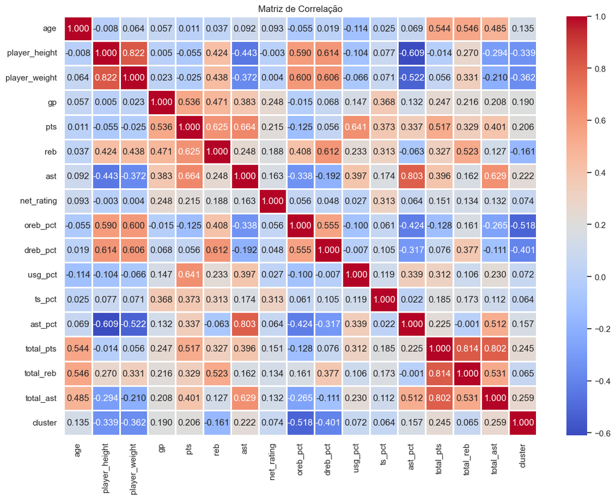

```python
correlation(scaled_df, 14, 10, '3')
```

# Correlações

Destaco algumas correlações de dados significativas que foram identificadas em nossa análise estatística. Essas correlações são fundamentais para compreender as relações entre diferentes variáveis em nosso conjunto de dados. Aqui estão as correlações mais relevantes:

**Correlação Moderada entre Idade (Age) e Pontos Totais (Total_Pts): 0.544**

**Correlação Moderada entre Idade (Age) e Rebotes Totais (Total_Reb): 0.546**

- Há uma correlação moderada entre a idade dos jogadores e o número total de rebotes. Isso sugere que a idade pode influenciar o desempenho dos jogadores nesse aspecto.

**Correlação Moderada entre Idade (Age) e Assistências Totais (Total_Ast): 0.485**

**Correlação Forte entre Altura (Player_Height) e Peso (Player_Weight): 0.822**

- Existe uma correlação forte entre a altura e o peso dos jogadores. Isso indica que jogadores mais altos geralmente tendem a ter um peso mais elevado, o que é uma observação lógica.

**Correlação Moderada entre Altura (Player_Height) e Rebotes (Reb): 0.424**

- A altura dos jogadores tem uma correlação moderada com o número de rebotes, sugerindo que jogadores mais altos podem ter uma ligeira vantagem nesse aspecto.

**Correlação Moderada entre Altura (Player_Height) e Assistências (Ast): -0.443**

- Existe uma correlação moderada negativa entre a altura dos jogadores e o número de assistências. Isso indica que jogadores mais baixos podem ser mais eficazes em fornecer assistências.

**Correlação Moderada entre Altura (Player_Height) e Percentagem de Rebotes Ofensivos (Oreb_Pct): 0.590**

- A altura dos jogadores tem uma correlação moderada com a percentagem de rebotes ofensivos. Jogadores mais altos podem ter uma ligeira vantagem na obtenção de rebotes ofensivos.

**Correlação Moderada entre Altura (Player_Height) e Percentagem de Rebotes Defensivos (Dreb_Pct): 0.614**

- A altura dos jogadores também tem uma correlação moderada com a percentagem de rebotes defensivos. Jogadores mais altos podem ter uma ligeira vantagem na obtenção de rebotes defensivos.

**Correlação Moderada entre Altura (Player_Height) e Percentagem de Assistências (Ast_Pct): -0.609**

- A altura dos jogadores está correlacionada de forma moderada negativa com a percentagem de assistências. Isso sugere que jogadores mais baixos podem ser mais eficazes na criação de jogadas de equipe.

- A altura dos jogadores tem uma correlação moderada negativa com a atribuição a clusters específicos. Isso pode indicar que jogadores mais altos possuem características distintas em relação à pertinência a determinados grupos.

**Correlação Forte entre Peso (Player_Weight) e Altura (Player_Height): 0.822**

- Existe uma forte correlação entre o peso e a altura dos jogadores. Jogadores mais pesados tendem a ser mais altos, o que é uma observação coerente.

**Correlação Moderada entre Peso (Player_Weight) e Rebotes (Reb): 0.438**

- O peso dos jogadores tem uma correlação moderada com o número de rebotes, sugerindo que jogadores mais pesados podem ter uma ligeira vantagem nesse aspecto.

**Correlação Moderada entre Peso (Player_Weight) e Percentagem de Rebotes Ofensivos (Oreb_Pct): 0.600**

- A correlação moderada entre o peso e a percentagem de rebotes ofensivos sugere que jogadores mais pesados podem ser mais eficazes na obtenção desses rebotes.

O código abaixo é usado para identificar jogadores que pertencem a múltiplos "clusters" em um conjunto de dados. Ele realiza uma análise de dados, filtrando e classificando os jogadores com base no número de clusters únicos aos quais pertencem. Isso pode ser valioso para identificar jogadores versáteis em diferentes contextos.

```python
jogadoresMultiClusters = (df.groupby('player_name')['cluster'].nunique()
 [df.groupby('player_name')['cluster']
  .nunique() > 1]
 .sort_values(ascending=False)
)
```

# Análise das Médias de Pontos, Rebotes e Assistências de Tracy McGrady ao Longo das Temporadas

Neste gráfico de linha, explorei as médias do desempenho do jogador **Tracy McGrady** em três estatísticas-chave: pontos (Pts), rebotes (Reb) e assistências (Ast) ao longo de várias temporadas. O jogador foi selecionado para análise pois foi clusterizado pelo algoritmo em 5 grupos durante sua carreira. Cada temporada é representada no eixo horizontal (X), enquanto as médias são exibidas no eixo vertical (Y).

```python
for jogador in jogadoresMultiClusters[jogadoresMultiClusters.values == 5].index:
    print(jogador)
```

```
Tracy McGrady
Matt Harpring
Danny Granger
Gerald Wallace
Kevin Martin
```

```python
tracy_data = (df.query('player_name == "Tracy McGrady"')
                .sort_values(by='season')
                .reset_index(drop=True)
                .copy())
```

```python
tracy_data.head(15)
```

|  | player_name | team_abbreviation | age | player_height | player_weight | college | country | draft_year | draft_round | draft_number | ... | oreb_pct | dreb_pct | usg_pct | ts_pct | ast_pct | season | total_pts | total_reb | total_ast | cluster |
| --- | --- | --- | --- | --- | --- | --- | --- | --- | --- | --- | --- | --- | --- | --- | --- | --- | --- | --- | --- | --- | --- |
| 0 | Tracy McGrady | TOR | 19.0 | 203.2 | 95.254320 | None | USA | 1997 | 1 | 9 | ... | 0.095 | 0.155 | 0.187 | 0.505 | 0.136 | 1997-98 | 7.0 | 4.2 | 1.5 | 6 |
| 1 | Tracy McGrady | TOR | 20.0 | 203.2 | 95.254320 | None | USA | 1997 | 1 | 9 | ... | 0.123 | 0.169 | 0.214 | 0.504 | 0.187 | 1998-99 | 16.3 | 9.9 | 3.8 | 0 |
| 2 | Tracy McGrady | TOR | 21.0 | 203.2 | 95.254320 | None | USA | 1997 | 1 | 9 | ... | 0.084 | 0.146 | 0.246 | 0.509 | 0.192 | 1999-00 | 31.7 | 16.2 | 7.1 | 1 |
| 3 | Tracy McGrady | ORL | 22.0 | 203.2 | 95.254320 | None | USA | 1997 | 1 | 9 | ... | 0.067 | 0.142 | 0.311 | 0.521 | 0.218 | 2000-01 | 58.5 | 23.7 | 11.7 | 1 |
| 4 | Tracy McGrady | ORL | 23.0 | 203.2 | 95.254320 | None | USA | 1997 | 1 | 9 | ... | 0.057 | 0.171 | 0.311 | 0.532 | 0.250 | 2001-02 | 84.1 | 31.5 | 17.0 | 5 |
| 5 | Tracy McGrady | ORL | 24.0 | 203.2 | 95.254320 | None | USA | 1997 | 1 | 9 | ... | 0.046 | 0.147 | 0.350 | 0.564 | 0.282 | 2002-03 | 116.2 | 38.0 | 22.5 | 5 |
| 6 | Tracy McGrady | ORL | 25.0 | 203.2 | 95.254320 | None | USA | 1997 | 1 | 9 | ... | 0.039 | 0.131 | 0.330 | 0.526 | 0.272 | 2003-04 | 144.2 | 44.0 | 28.0 | 5 |
| 7 | Tracy McGrady | HOU | 26.0 | 203.2 | 95.254320 | None | USA | 1997 | 1 | 9 | ... | 0.027 | 0.149 | 0.309 | 0.526 | 0.276 | 2004-05 | 169.9 | 50.2 | 33.7 | 5 |
| 8 | Tracy McGrady | HOU | 27.0 | 203.2 | 95.254320 | None | USA | 1997 | 1 | 9 | ... | 0.031 | 0.173 | 0.344 | 0.494 | 0.268 | 2005-06 | 194.3 | 56.7 | 38.5 | 5 |
| 9 | Tracy McGrady | HOU | 28.0 | 203.2 | 101.151016 | None | USA | 1997 | 1 | 9 | ... | 0.025 | 0.143 | 0.347 | 0.515 | 0.353 | 2006-07 | 218.9 | 62.0 | 45.0 | 5 |
| 10 | Tracy McGrady | HOU | 29.0 | 203.2 | 101.151016 | None | USA | 1997 | 1 | 9 | ... | 0.019 | 0.134 | 0.303 | 0.487 | 0.294 | 2007-08 | 240.5 | 67.1 | 50.9 | 5 |
| 11 | Tracy McGrady | HOU | 30.0 | 203.2 | 101.151016 | None | USA | 1997 | 1 | 9 | ... | 0.020 | 0.125 | 0.245 | 0.492 | 0.256 | 2008-09 | 256.1 | 71.5 | 55.9 | 5 |
| 12 | Tracy McGrady | NYK | 31.0 | 203.2 | 101.151016 | None | USA | 1997 | 1 | 9 | ... | 0.038 | 0.124 | 0.208 | 0.466 | 0.220 | 2009-10 | 264.3 | 74.6 | 59.2 | 4 |
| 13 | Tracy McGrady | DET | 32.0 | 203.2 | 101.151016 | None | USA | 1997 | 1 | 9 | ... | 0.034 | 0.155 | 0.189 | 0.503 | 0.244 | 2010-11 | 272.3 | 78.1 | 62.7 | 4 |
| 14 | Tracy McGrady | ATL | 33.0 | 203.2 | 102.058200 | None | USA | 1997 | 1 | 9 | ... | 0.033 | 0.176 | 0.182 | 0.510 | 0.221 | 2011-12 | 277.6 | 81.1 | 64.8 | 4 |

15 rows × 25 columns

```python
tracy_data = tracy_data.sort_values(by=['season', 'cluster'])
```

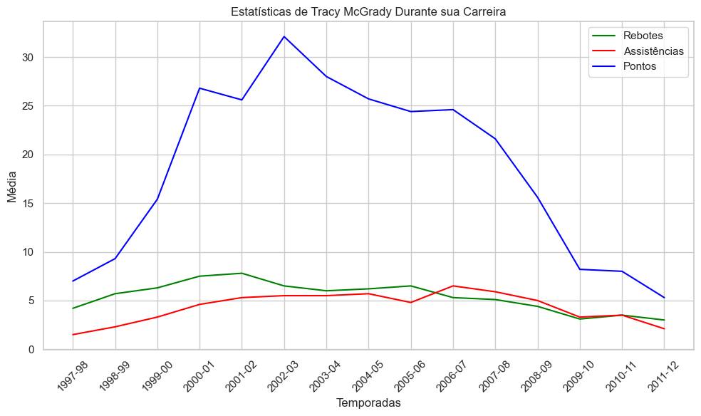

```python
plt.figure(figsize=(10,6))
sns.lineplot(x='season', y='reb',
             data=tracy_data,
             color='green',
             label='Rebotes')
sns.lineplot(x='season', y='ast',
             data=tracy_data,
             color='red', label='Assistências')
sns.lineplot(x='season', y='pts',
             data=tracy_data,
             color='blue', label='Pontos')
plt.title('Estatísticas de Tracy McGrady Durante sua Carreira')
plt.ylabel('Média')
plt.xlabel('Temporadas')
plt.xticks(rotation=45)
plt.tight_layout()
plt.show();
```